# R Notebook

# (d) Calculate and plot the sample PACF for your simulated series. How well do the values and patterns match the theoretical ACF from part (c)?

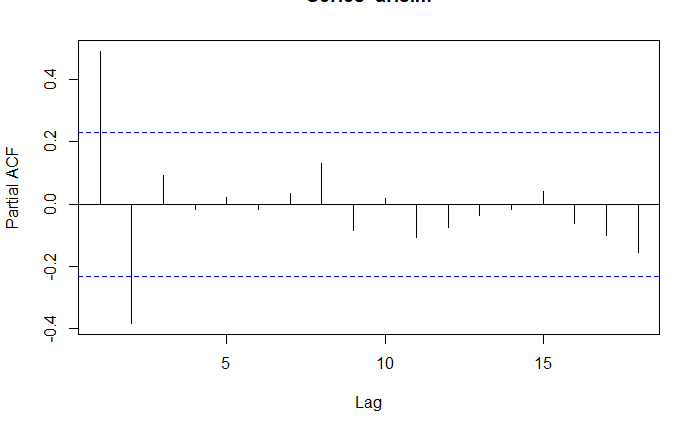

```r
ar.acf <- acf(ar.sim, type="partial", plot=TRUE)
```

# Here PACF is having importance to make decision to find the number of lags and the PACF of +/- 0.22 indicates the blue boundry below which the lags are not

# significant which indeed states that it’s a 2 lag AR process since we have only 2 lags which are cutting the blue line of PACF. You don’t consider ACF here since it has correlation effect of 2nd event on the 3rd and so on and so we take our decision based upon the PACF for AR series.

# ———————– Q 7 ————————-

# 7. Simulate an MA(2) time series of length n = 36 with θ1 = 0.7 and θ2 = −0.4.

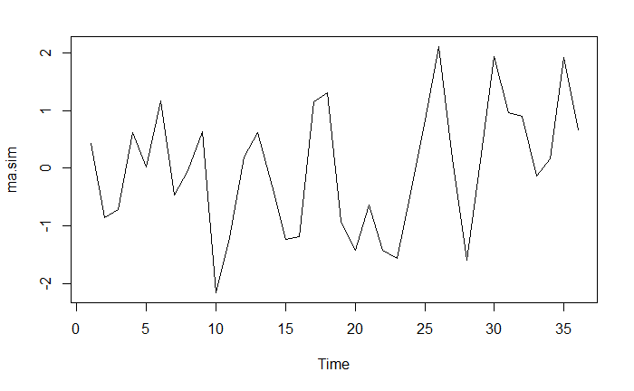

```r
set.seed(3) # setting seed
ma.sim<-arima.sim(model=list(ma=c(.7,-.4)),n=36)
#Visualize the time series plot
plot(ma.sim)
```

# (a) What are the theoretical autocorrelations for this model?

```r
ARMAacf(c(0.7, -0.4), lag.max=15, pacf=FALSE)
```

```
            0             1             2             3             4             5             6             7             8             9            10            11
 1.0000000000  0.5000000000 -0.0500000000 -0.2350000000 -0.1445000000 -0.0071500000  0.0527950000  0.0398165000  0.0067535500 -0.0111991150 -0.0105408005 -0.0028989143
           12            13            14            15
 0.0021870802  0.0026905218  0.0010085332 -0.0003702355
```

# (b) Calculate and plot the sample ACF for your simulated series. How well do the values and patterns match the theoretical ACF from part (a)?

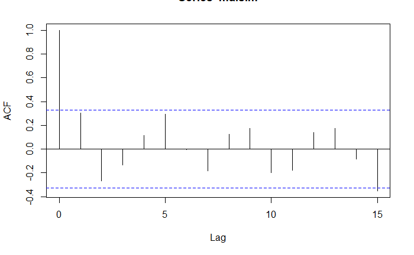

```r
acf=acf(ma.sim)
```

#ACF values

```r
acf$acf
```

```
, , 1

              [,1]
 [1,]  1.000000000
 [2,]  0.304801649
 [3,] -0.268807540
 [4,] -0.132848021
 [5,]  0.114319255
 [6,]  0.291626376
 [7,] -0.002140123
 [8,] -0.183367628
 [9,]  0.123058268
[10,]  0.172746382
[11,] -0.198686682
[12,] -0.178324962
[13,]  0.137813478
[14,]  0.172241517
[15,] -0.082255768
[16,] -0.350662576
```